**Instructor copy.** Executed notebook with all results shown, including the "after your attempt" cells. Projector/offline fallback; learners should use the notebook itself.

# f8 · Two candidate boundary states

**Learning question:** the same invented boundary could take one of two structures. Which one has the lower energy, and what must be held the same before two energies may be compared at all?

Used in: Day 2 D7, Lesson 14, Clinic D, self-study step 04 extension. It continues f7: same cell, same bulk, closed inventory. Work each "your turn" on paper first, then type your value; four significant figures are enough unless a question asks for more. Labels such as (W4), (D1), (Lesson 5) or Clinic D point to the printed one-day primers (Day 1 and Day 2 worksheets) and the detailed lessons of the classroom course in the repository. Working alone on the website, you only need the step numbers.

**The idea.** A grain boundary can sometimes exist in more than one atomic arrangement. Each arrangement has its own energy and its own liking for B. Which one is stable can depend on how much B is around, so the stable arrangement can switch as the composition changes. Here two invented arrangements, State I and State II, are compared in the closed cell of f7. The main lesson is about fair comparison: two energies may be compared only when they describe the same cell, on the same basis, each at its own minimum.

**The route through the notebook.**

1. Define both states and the shared inventory.
2. Let each state settle separately, then compare the two energies.
3. Scan the starting composition to find where the lower state switches.
4. Practise on a fresh card, then compare with the course code and pictures.

Run the setup cell first; it makes the helpers `check` and `confirm` available.

```python
# Setup: run this cell first. Locally it finds the course folder; in Colab it
# downloads the tested course release and the locked package versions.
# In Colab, the first run then restarts the session on purpose and Colab reports
# a crash: that is expected. Run this cell again, then the rest of the notebook.
RELEASE = "main"
import os, pathlib, subprocess, sys, time
ROOT = next((p for p in (pathlib.Path.cwd(), *pathlib.Path.cwd().parents)
             if (p / "pyproject.toml").is_file() and (p / "course").is_dir()), None)
if ROOT is None and "google.colab" in sys.modules:
    ROOT = pathlib.Path("/content/CalphadIntro")
    if not ROOT.is_dir():
        clone = ["git", "clone", "-q", "--depth", "1", "--branch", RELEASE,
                 "https://github.com/ukerzel/CalphadIntro.git", str(ROOT)]
        git = dict(os.environ, GIT_TERMINAL_PROMPT="0")
        if subprocess.run(clone, env=git, capture_output=True).returncode:
            raise SystemExit(f"Could not download course release {RELEASE}: check the internet "
                             "connection and run this cell again.")
    if not (ROOT / ".colab-ready").exists():
        if subprocess.run([sys.executable, "-m", "pip", "install", "-q", "-r",
                           str(ROOT / "notebooks" / "requirements-colab.txt")]).returncode:
            raise SystemExit("Installing the course packages failed; run this cell again.")
        (ROOT / ".colab-ready").touch()
        # Colab has already loaded its own numpy; a fresh session is needed to use the installed versions.
        print("Installed the course's package versions. Colab now restarts this session and"
              " reports a crash; that is expected. When it has reconnected, run this cell again"
              " (it will not install twice), then the rest of the notebook.", flush=True)
        time.sleep(3)
        os.kill(os.getpid(), 9)
if ROOT is None:
    raise SystemExit("Open this notebook from the course folder (poetry run jupyter lab) or in Colab.")
os.chdir(ROOT)
sys.path.insert(0, str(ROOT))
from notebooks.helpers import check, confirm, database, show_versions
show_versions(RELEASE)
```

```
Course release main · Python 3.12.14
  numpy       2.5.3
  scipy       1.18.1
  matplotlib  3.11.2
  xarray      2026.7.0
  pycalphad   0.11.2
```

```
True
```

## 1. Two states on one basis (D7, Lesson 14A)

The cell is the one from f7: T = 1000 K, p = 100000 Pa, 8000 bulk sites and two equivalent boundaries of 100 sites and 20 nm² each, every site holding one A or one B atom. The bulk is the invented ideal ALPHA curve (J/mol of sites, $RT=8314.5$ J/mol):

$$g_b(x)=-9000+12000\,x+RT\,[x\ln x+(1-x)\ln(1-x)].$$

Both boundaries take **one** of two invented structures. Each structure has its own baseline $\eta_i$ and B preference $\delta_i$:

$$g_{s,i}(\theta)=g_b(\theta)+\eta_i+\delta_i\,\theta .$$

| State | baseline $\eta_i$ (J/mol boundary sites) | preference $\delta_i$ (J/mol boundary sites) |
| --- | --- | --- |
| I | 0 | −5000 |
| II | +2000 | −10000 |

State II pays a baseline but likes B more. Neither number is measured.

**What is held the same.** For a chosen start $x_0$, both states start with $\theta_0=0.25$ on both boundaries, so they share one closed inventory $B_{\rm tot}=8000x_0+200(0.25)=8000x_0+50$. Each state then settles on its own $\theta$ and its own final bulk fraction $x_b=(B_{\rm tot}-200\theta)/8000$. The energy compared is the closed-cell energy per mole of **all 8200 cell sites** (f7, section 3), now with the baseline included:

$$\bar g_i(\theta)=\frac{8000\,g_b[x_b(\theta)]+200\,g_{s,i}(\theta)}{8200}.$$

The baseline does not depend on $\theta$, so it does not move the selected occupancy; it only shifts the energy, by $200\,\eta_i/8200$ J/mol all cell sites.

Reminder of the symbols from f7: $\theta$ is the fraction of boundary sites that hold B, $x_b$ the fraction of bulk sites that hold B, and a negative $\delta$ means the boundary prefers B. The index $i$ stands for I or II.

**The trade-off.** State II pays its baseline $\eta_{II}$ on every boundary site, whatever it holds, but gains $\delta_{II}\theta$, which grows with the amount of B on the boundary. How much B the boundary can take depends on how much B the cell has, so the balance between cost and gain can depend on the inventory. Which state wins, and for which inventories, is what this notebook calculates.

**New Python in this cell.** `STATES` is a dictionary from the state's name to a pair `(δ, η)`. `STATES.items()` gives the name and the pair together, and `for name, (delta, eta) in ...` unpacks the pair into two names. In `g_bar(trial, 850, *STATES['I'])` the star unpacks the pair into the last two arguments, so it means `g_bar(trial, 850, -5000.0, 0.0)`.

The last lines print **unrelaxed** trials: both states at a few chosen occupancies, not at their minima. They show how ḡ depends on θ, but they are not yet the energies to compare.

```python
import numpy as np

RT = 8.3145 * 1000.0                     # J/mol at T = 1000 K
N_BULK, N_BOUNDARY = 8000, 200           # bulk sites; sites on both boundaries
N_SITES = N_BULK + N_BOUNDARY            # 8200 cell sites
THETA_0 = 0.25                           # starting boundary occupancy
STATES = {"I": (-5000.0, 0.0),           # (δ, η) in J/mol boundary sites
          "II": (-10000.0, 2000.0)}

def g_bulk(x):
    return -9000.0 + 12000.0 * x + RT * (x * np.log(x) + (1 - x) * np.log(1 - x))   # J/mol sites

def g_site(theta, delta, eta):
    return g_bulk(theta) + eta + delta * theta                                        # J/mol boundary sites

def B_total(x0):
    return N_BULK * x0 + N_BOUNDARY * THETA_0                                         # B atoms in the cell

def x_bulk(theta, B_tot):
    return (B_tot - N_BOUNDARY * theta) / N_BULK                                      # B per bulk site

def g_bar(theta, B_tot, delta, eta):
    xb = x_bulk(theta, B_tot)   # the bulk keeps whatever B the boundaries do not hold
    return (N_BULK * g_bulk(xb) + N_BOUNDARY * g_site(theta, delta, eta)) / N_SITES  # J/mol all cell sites

for name, (delta, eta) in STATES.items():
    print(f"State {name}: δ = {delta:7.0f}, η = {eta:5.0f} J/mol boundary sites")
print(f"Shared inventory: x0 = 0.10 gives B_tot = {B_total(0.10):.0f}; x0 = 0.25 gives {B_total(0.25):.0f}")
print("\nUnrelaxed trials at B_tot = 850 (not yet minima):")
for trial in (0.15, 0.20, 0.30, 0.35):
    print(f"  θ = {trial:.2f}: ḡ_I = {g_bar(trial, 850, *STATES['I']):.4f}, "
          f"ḡ_II = {g_bar(trial, 850, *STATES['II']):.4f} J/mol all cell sites")
```

```
State I: δ =   -5000, η =     0 J/mol boundary sites
State II: δ =  -10000, η =  2000 J/mol boundary sites
Shared inventory: x0 = 0.10 gives B_tot = 850; x0 = 0.25 gives 2050

Unrelaxed trials at B_tot = 850 (not yet minima):
  θ = 0.15: ḡ_I = -10541.3690, ḡ_II = -10510.8812 J/mol all cell sites
  θ = 0.20: ḡ_I = -10541.1526, ḡ_II = -10516.7623 J/mol all cell sites
  θ = 0.30: ḡ_I = -10531.1899, ḡ_II = -10518.9948 J/mol all cell sites
  θ = 0.35: ḡ_I = -10522.2140, ḡ_II = -10516.1164 J/mol all cell sites
```

Among these trials each state has its own θ at which ḡ is lowest, and State II's lowest trial lies at a higher θ than State I's, because it prefers B more. The fair comparison takes each state at its own lowest point, which is the next step.

## 2. Let each state settle, then compare (D7)

Each state is minimised **separately** at the shared inventory. As in f7, the minimum satisfies the exchange condition $g_{s,i}'(\theta)=g_b'(x_b)$, which gives the odds formula with that state's own preference:

$$\frac{\theta}{1-\theta}=\frac{x_b}{1-x_b}\,\exp(-\delta_i/RT), \qquad x_b=\frac{B_{\rm tot}-200\theta}{8000}.$$

The hand method from f7 repeats: odds formula at the current $x_b$, then update $x_b$ from the fixed inventory. The cell below runs that loop for both states. Compare the two settled energies with

$$D=\bar g_{II}^*-\bar g_I^*\quad\text{at one } x_0 .$$

Positive $D$: State I is lower. Negative $D$: State II is lower.

The star in $\bar g^*$ and $\theta^*$ marks the settled (minimum) value. The function `settle` runs 60 rounds of the hand method, far more than needed, and returns three values: the settled θ, the final $x_b$ and the settled ḡ. In `for _ in range(rounds):` the underscore is a name for a loop counter that is not used. The text in triple quotes right under `def` is a *docstring*, a short description of the function.

The printed table has one row per start $x_0$ and state. Compare the two states only **within** the same $x_0$ (the same $B_{\rm tot}$).

```python
def settle(x0, delta, eta, rounds=60):
    """Hand iteration at fixed inventory: odds formula, then update x_b."""
    B_tot = B_total(x0)   # fixed for this cell
    xb = x0               # round 1 starts from the starting bulk fraction
    for _ in range(rounds):
        odds = xb / (1 - xb) * np.exp(-delta / RT)   # odds formula with this state's δ
        theta = odds / (1 + odds)
        xb = x_bulk(theta, B_tot)                    # the bulk gives up (or takes back) B
    return theta, xb, g_bar(theta, B_tot, delta, eta)   # θ*, final x_b, ḡ* in J/mol all cell sites

print("x0     B_tot   state  θ*           ḡ* (J/mol all cell sites)")
for x0 in (0.10, 0.25):
    for name, (delta, eta) in STATES.items():
        theta, xb, g = settle(x0, delta, eta)
        print(f"{x0:.2f}   {B_total(x0):5.0f}   {name:<5}  {theta:.8f}   {g:.5f}")   # {name:<5}: left-aligned, 5 wide
```

```
x0     B_tot   state  θ*           ḡ* (J/mol all cell sites)
0.10     850   I      0.17160752   -10541.72679
0.10     850   II     0.26898261   -10519.50695
0.25    2050   I      0.37428127   -10713.32958
0.25    2050   II     0.51703770   -10718.80845
```

### Your turn

Use the settled values printed above (they are the D7 table).

1. $D$ at $x_0=0.10$ and at $x_0=0.25$; name the lower state in each row (`"I"` or `"II"`). Is "State II at $x_0=0.25$ minus State I at $x_0=0.10$" a meaningful comparison?
2. Row $x_0=0.10$: State II's boundary B count, its bulk B count and its final $x_b$; State I's bulk B count. Could both states keep the same final $x_b$ and still hold 850 B each?
3. A report drops $\eta_{II}$. What is State II's energy at $x_0=0.10$ without the baseline, and which state would that report call lower?
4. Someone compares both states at the unrelaxed start $\theta=0.25$ in the $x_0=0.25$ cell. What $D$ do they get, and which state would they pick?

The three cells below hold the answers to questions 1, 2 and 3–4. Names of states are text, so type them with quotes: `"I"` or `"II"`. For the counts in question 2, $\theta$ is a fraction of the 200 boundary sites and $x_b$ a fraction of the 8000 bulk sites. For question 4 you can evaluate any occupancy with `g_bar(theta, B_tot, delta, eta)`.

```python
# Question 1
D_010 = None                  # J/mol all cell sites
lower_010 = None              # "I" or "II"
D_025 = None                  # J/mol all cell sites
lower_025 = None              # "I" or "II"
cross_row_meaningful = None   # True or False
check(D_010, "f8_d7_D_010")
check(lower_010, "f8_d7_lower_010")
check(D_025, "f8_d7_D_025")
check(lower_025, "f8_d7_lower_025")
check(cross_row_meaningful, "f8_d7_cross_row")
```

```
f8_d7_D_010: not attempted yet. Replace None with your value and run the cell again.
f8_d7_lower_010: not attempted yet. Replace None with your value and run the cell again.
f8_d7_D_025: not attempted yet. Replace None with your value and run the cell again.
f8_d7_lower_025: not attempted yet. Replace None with your value and run the cell again.
f8_d7_cross_row: not attempted yet. Replace None with your value and run the cell again.
```

```python
# Question 2 (row x0 = 0.10, 850 B in the cell)
boundary_B_II = None          # B atoms on both boundaries, State II, 850 B
bulk_B_II = None              # B atoms in the bulk, State II
x_b_II = None                 # B per bulk site, State II
bulk_B_I = None               # B atoms in the bulk, State I
same_x_b_possible = None      # True or False
check(boundary_B_II, "f8_d7_boundary_B_II")
check(bulk_B_II, "f8_d7_bulk_B_II")
check(x_b_II, "f8_d7_x_b_II")
check(bulk_B_I, "f8_d7_bulk_B_I")
check(same_x_b_possible, "f8_d7_same_x_b")
```

```
f8_d7_boundary_B_II: not attempted yet. Replace None with your value and run the cell again.
f8_d7_bulk_B_II: not attempted yet. Replace None with your value and run the cell again.
f8_d7_x_b_II: not attempted yet. Replace None with your value and run the cell again.
f8_d7_bulk_B_I: not attempted yet. Replace None with your value and run the cell again.
f8_d7_same_x_b: not attempted yet. Replace None with your value and run the cell again.
```

```python
# Questions 3 and 4
baseline_all_sites = None     # J/mol all cell sites, η_II = 2000
g_II_no_baseline = None       # J/mol all cell sites, x0 = 0.10
lower_no_baseline = None      # "I" or "II"
D_unrelaxed_025 = None        # J/mol all cell sites, both at θ = 0.25, x0 = 0.25
lower_unrelaxed_025 = None    # "I" or "II"
check(baseline_all_sites, "f8_d7_baseline")
check(g_II_no_baseline, "f8_d7_g_II_no_baseline")
check(lower_no_baseline, "f8_d7_lower_no_baseline")
check(D_unrelaxed_025, "f8_l14_D_unrelaxed")
check(lower_unrelaxed_025, "f8_l14_lower_unrelaxed")
```

```
f8_d7_baseline: not attempted yet. Replace None with your value and run the cell again.
f8_d7_g_II_no_baseline: not attempted yet. Replace None with your value and run the cell again.
f8_d7_lower_no_baseline: not attempted yet. Replace None with your value and run the cell again.
f8_l14_D_unrelaxed: not attempted yet. Replace None with your value and run the cell again.
f8_l14_lower_unrelaxed: not attempted yet. Replace None with your value and run the cell again.
```

## 3. Where does the order switch? (Lesson 14B)

$D$ is positive at $x_0=0.10$ and negative at $x_0=0.25$, so it changes sign somewhere in between. Each $x_0$ is a **different** closed cell; the scan below simply repeats the same-inventory comparison for several cells from 0.10 to 0.35.

`D_at(x0)` settles both states in the cell that starts at `x0` and returns $D$. Its second argument `eta_II` has the default 2000 J/mol; `D_at(x0, eta_II=2100.0)` repeats the comparison with a different baseline for State II. `np.round(..., 2)` rounds the start values to two decimals, so that they print as 0.15 and not 0.15000000000000002 (decimal fractions are not exact in binary arithmetic).

```python
starts = np.round(np.arange(0.10, 0.351, 0.05), 2)   # 6 starting bulk fractions, 0.10 to 0.35

def D_at(x0, eta_II=2000.0):
    g_I = settle(x0, -5000.0, 0.0)[2]          # [2] picks ḡ* from (θ*, x_b, ḡ*)
    g_II = settle(x0, -10000.0, eta_II)[2]
    return g_II - g_I                                   # J/mol all cell sites

print("x0     B_tot   D = ḡ_II* − ḡ_I* (J/mol all cell sites)")
for x0 in starts:
    print(f"{x0:.2f}   {B_total(x0):5.0f}   {D_at(x0):9.4f}")
```

```
x0     B_tot   D = ḡ_II* − ḡ_I* (J/mol all cell sites)
0.10     850     22.2198
0.15    1250     11.9396
0.20    1650      2.7633
0.25    2050     -5.4789
0.30    2450    -12.9239
0.35    2850    -19.6829
```

### Your turn

1. Find the crossing $x_0$ (where $D=0$) to four decimals. Halve the interval by hand with `D_at`, or write a short loop.
2. Change **only** $\eta_{II}$ from 2000 to 2100 J/mol boundary sites. By how much does $D$ shift at any fixed $x_0$? Does State II's selected $\theta$ change? Where does the crossing move (four decimals)?

**Halving the interval (bisection).** Take two starts from the table, `lo` with $D>0$ and `hi` with $D<0$. The crossing lies between them. Evaluate $D$ at the midpoint; if it is positive the crossing lies above the midpoint, so the midpoint becomes the new `lo`, otherwise the new `hi`. Each round halves the interval. As a loop (fill in `lo` and `hi` from the table):

```
lo, hi = ..., ...
for _ in range(20):
    mid = (lo + hi) / 2
    if D_at(mid) > 0:
        lo = mid
    else:
        hi = mid
print(lo, hi)
```

After 20 halvings the interval is about a millionth of its starting width. For question 2, look at the exchange condition of section 2 and ask which terms $\eta$ appears in.

```python
x0_crossing = None            # starting bulk B fraction where D = 0
D_shift_2100 = None           # J/mol all cell sites
theta_II_changes = None       # True or False
x0_crossing_2100 = None       # starting bulk B fraction, η_II = 2100
check(x0_crossing, "f8_l14_crossing")
check(D_shift_2100, "f8_l14_shift_2100")
check(theta_II_changes, "f8_l14_theta_changes")
check(x0_crossing_2100, "f8_l14_crossing_2100")
```

```
f8_l14_crossing: not attempted yet. Replace None with your value and run the cell again.
f8_l14_shift_2100: not attempted yet. Replace None with your value and run the cell again.
f8_l14_theta_changes: not attempted yet. Replace None with your value and run the cell again.
f8_l14_crossing_2100: not attempted yet. Replace None with your value and run the cell again.
```

## 4. A fresh card from Clinic D

Same model, a new closed cell started at $x_0=0.40$, $\theta_0=0.25$. The separately settled values are supplied:

| State | $\theta^*$ | final $x_b$ | $\bar g^*$ (J/mol all cell sites) |
| --- | --- | --- | --- |
| I | 0.54127054 | 0.39271824 | −9884.21053 |
| II | 0.67967666 | 0.38925808 | −9910.05801 |

Find total B and total A, check the B balance of each state, then $D$ and the lower state. Give State II's equal-site excess $5(\theta-x_b)$ in atom/nm² (f7, section 1). Finally write two sentences for a presenter who calls this a measured Ni–Cu result and the switch a confirmed boundary transition: one thing this invented model does show, and one missing piece of evidence.

The **B balance** is the check that no atoms were lost or created: boundary B plus bulk B, $200\,\theta^*+8000\,x_b$, must equal the total B of the cell for each state.

```python
card_total_B = None           # B atoms in the cell
card_total_A = None           # A atoms in the cell
card_D = None                 # J/mol all cell sites
card_lower = None             # "I" or "II"
card_excess_II = None         # atom/nm²
check(card_total_B, "f8_clinic_total_B")
check(card_total_A, "f8_clinic_total_A")
check(card_D, "f8_clinic_D")
check(card_lower, "f8_clinic_lower")
check(card_excess_II, "f8_clinic_excess_II")
```

```
f8_clinic_total_B: not attempted yet. Replace None with your value and run the cell again.
f8_clinic_total_A: not attempted yet. Replace None with your value and run the cell again.
f8_clinic_D: not attempted yet. Replace None with your value and run the cell again.
f8_clinic_lower: not attempted yet. Replace None with your value and run the cell again.
f8_clinic_excess_II: not attempted yet. Replace None with your value and run the cell again.
```

## 5. After your attempt: the course code and the pictures

The course module `boundary_two_state` minimises each state's full closed-cell energy with a bounded minimiser (not the hand iteration above) and brackets the crossing with a root finder.

- `compare_states(x0, eta_II=2000)` settles both states in the cell that starts at `x0` and returns a dictionary: `pair["I"]` and `pair["II"]` hold each state's `theta`, `x_bulk` and `G_molar_J_per_mol_sites` (ḡ*), and `pair["difference_J_per_mol_sites"]` is $D$.
- `crossing(eta_II)` finds the $x_0$ where $D=0$ with a **root finder** (`scipy.optimize.brentq`): like the bisection above, it keeps an interval in which $D$ changes sign and shrinks it, but faster. `cross[eta]["x_initial"]` is the crossing.

The cell confirms the D7 table, the B balances, the baseline effect, the crossing for three baselines and the Clinic D cards, then draws two panels:

- **left:** the settled energies of both states against $x_0$. Each point is a different closed cell; the two curves are close, so their difference is hard to see on this scale;
- **right:** $D$ itself for three values of $\eta_{II}$. Above the zero line State I is lower, below it State II. The × marks the crossing. A larger baseline shifts the whole $D$ curve up by the same amount and moves the crossing to higher $x_0$.

```
x0 = 0.10: θ_I = 0.17160753, ḡ_I = -10541.72679; θ_II = 0.26898258, ḡ_II = -10519.50695; D = +22.21984 J/mol all cell sites
✓ θ_I at x0 = 0.10 reproduces the lesson value.
✓ θ_II at x0 = 0.10 reproduces the lesson value.
✓ ḡ_I at x0 = 0.10 reproduces the lesson value.
✓ ḡ_II at x0 = 0.10 reproduces the lesson value.
✓ D at x0 = 0.10 reproduces the lesson value.
✓ D at x0 = 0.10 from the hand iteration above reproduces the lesson value.
x0 = 0.25: θ_I = 0.37428128, ḡ_I = -10713.32958; θ_II = 0.51703766, ḡ_II = -10718.80845; D = -5.47887 J/mol all cell sites
✓ θ_I at x0 = 0.25 reproduces the lesson value.
✓ θ_II at x0 = 0.25 reproduces the lesson value.
✓ ḡ_I at x0 = 0.25 reproduces the lesson value.
✓ ḡ_II at x0 = 0.25 reproduces the lesson value.
✓ D at x0 = 0.25 reproduces the lesson value.
✓ D at x0 = 0.25 from the hand iteration above reproduces the lesson value.
State I at 850 B: boundary B = 34.321507, bulk B = 815.678493, x_b = 0.10195981
✓ B balance of State I reproduces the lesson value.
State II at 850 B: boundary B = 53.796516, bulk B = 796.203484, x_b = 0.09952544
✓ B balance of State II reproduces the lesson value.
✓ State II boundary B reproduces the lesson value.
✓ State II bulk B reproduces the lesson value.
✓ State I bulk B reproduces the lesson value.
✓ Baseline per mole of all cell sites reproduces the lesson value.
Without the baseline, State II at x0 = 0.10 would read -10568.28744 J/mol, below State I: the report would pick the wrong state.
Unrelaxed comparison at θ = 0.25, x0 = 0.25: D = +18.29268 J/mol (= 200(2000 − 5000·0.25)/8200), the opposite sign to the settled D.
✓ Crossing for η_II = 1900 reproduces the lesson value.
✓ Crossing for η_II = 2000 reproduces the lesson value.
✓ Crossing for η_II = 2100 reproduces the lesson value.
✓ θ_I at the crossing reproduces the lesson value.
✓ θ_II at the crossing reproduces the lesson value.
✓ D shift for η_II = 2100 reproduces the lesson value.
✓ Clinic D: D at x0 = 0.30 reproduces the lesson value.
✓ Clinic D: D at x0 = 0.40 reproduces the lesson value.
✓ Clinic D: State II excess at x0 = 0.40 reproduces the lesson value.
```

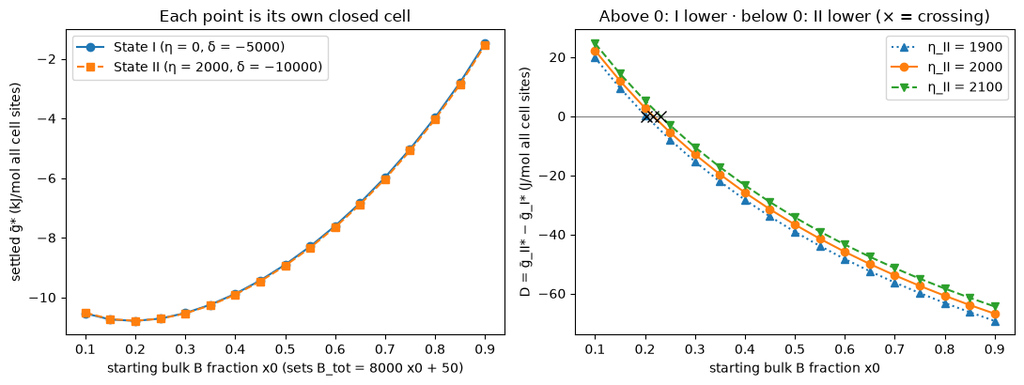

```
 x0    B_tot    ḡ_I*          ḡ_II*          D
 0.10    850  -10541.72679  -10519.50695  +22.21984
 0.15   1250  -10744.17124  -10732.23164  +11.93960
 0.20   1650  -10790.91356  -10788.15021   +2.76335
 0.25   2050  -10713.32958  -10718.80845   -5.47887
 0.30   2450  -10529.48099  -10542.40484  -12.92385
 0.35   2850  -10250.67476  -10270.35766  -19.68290
 0.40   3250   -9884.21053   -9910.05801  -25.84748
 0.45   3650   -9434.70900   -9466.20239  -31.49339
 0.50   4050   -8904.79653   -8941.48054  -36.68401
 0.55   4450   -8295.44491   -8336.91767  -41.47277
 0.60   4850   -7606.08798   -7651.99294  -45.90497
 0.65   5250   -6834.55267   -6884.57199  -50.01932
 0.70   5650   -5976.78241   -6030.63152  -53.84911
 0.75   6050   -5026.25731   -5083.68039  -57.42308
 0.80   6450   -3972.87216   -4033.63837  -60.76621
 0.85   6850   -2800.66864   -2864.56896  -63.90033
 0.90   7250   -1482.65683   -1549.50139  -66.84456
```

```python
#@title After your attempt: the D7 table, the baseline and the crossing
from course.foundations.boundary_two_state import compare_states, crossing
import matplotlib.pyplot as plt

# Lesson values for the two rows of the D7 table: (θ_I, ḡ_I, θ_II, ḡ_II, D).
lesson = {0.10: (0.17160753, -10541.72679, 0.26898258, -10519.50695, 22.21984),
          0.25: (0.37428128, -10713.32958, 0.51703766, -10718.80845, -5.47887)}
for x0, (th_I, g_I, th_II, g_II, D) in lesson.items():
    pair = compare_states(x0)   # course minimiser for both states at this inventory
    print(f"x0 = {x0:.2f}: θ_I = {pair['I']['theta']:.8f}, ḡ_I = {pair['I']['G_molar_J_per_mol_sites']:.5f}; "
          f"θ_II = {pair['II']['theta']:.8f}, ḡ_II = {pair['II']['G_molar_J_per_mol_sites']:.5f}; "
          f"D = {pair['difference_J_per_mol_sites']:+.5f} J/mol all cell sites")   # :+ always prints the sign
    confirm(pair["I"]["theta"], th_I, f"θ_I at x0 = {x0:.2f}", tol=1e-7)
    confirm(pair["II"]["theta"], th_II, f"θ_II at x0 = {x0:.2f}", tol=1e-7)
    confirm(pair["I"]["G_molar_J_per_mol_sites"], g_I, f"ḡ_I at x0 = {x0:.2f}", tol=1e-5)
    confirm(pair["II"]["G_molar_J_per_mol_sites"], g_II, f"ḡ_II at x0 = {x0:.2f}", tol=1e-5)
    confirm(pair["difference_J_per_mol_sites"], D, f"D at x0 = {x0:.2f}", tol=1e-5)
    # The hand iteration of section 2 must give the same D as the course minimiser.
    confirm(settle(x0, -10000.0, 2000.0)[2] - settle(x0, -5000.0, 0.0)[2], D,
            f"D at x0 = {x0:.2f} from the hand iteration above", tol=1e-5)

# Question 2: atom counts in the 850-B cell; boundary B + bulk B must be 850 for each state.
row = compare_states(0.10)
for name in ("I", "II"):
    s = row[name]
    print(f"State {name} at 850 B: boundary B = {200 * s['theta']:.6f}, bulk B = {8000 * s['x_bulk']:.6f}, x_b = {s['x_bulk']:.8f}")
    confirm(200 * s["theta"] + 8000 * s["x_bulk"], 850, f"B balance of State {name}", tol=1e-9)
confirm(200 * row["II"]["theta"], 53.796516, "State II boundary B", tol=1e-5)
confirm(8000 * row["II"]["x_bulk"], 796.203484, "State II bulk B", tol=1e-5)
confirm(8000 * row["I"]["x_bulk"], 815.678494, "State I bulk B", tol=1e-5)
# Questions 3 and 4: the baseline on the all-site basis, and the unrelaxed comparison.
confirm(200 * 2000 / 8200, 48.78049, "Baseline per mole of all cell sites", tol=1e-5)
print(f"Without the baseline, State II at x0 = 0.10 would read {-10519.50695 - 200 * 2000 / 8200:.5f} J/mol, "
      "below State I: the report would pick the wrong state.")
print(f"Unrelaxed comparison at θ = 0.25, x0 = 0.25: D = {g_bar(0.25, 2050, -10000, 2000) - g_bar(0.25, 2050, -5000, 0):+.5f} "
      "J/mol (= 200(2000 − 5000·0.25)/8200), the opposite sign to the settled D.")

# Section 3: the crossing for three baselines of State II.
cross = {}
for eta, expected in ((1900, 0.20187111), (2000, 0.21618678), (2100, 0.23094775)):
    cross[eta] = crossing(eta)
    confirm(cross[eta]["x_initial"], expected, f"Crossing for η_II = {eta}", tol=1e-8)
confirm(cross[2000]["I"]["theta"], 0.332074, "θ_I at the crossing", tol=1e-6)
confirm(cross[2000]["II"]["theta"], 0.470497, "θ_II at the crossing", tol=1e-6)
# Raising η_II by 100 J/mol shifts D by 200·100/8200 J/mol all cell sites.
shift = compare_states(0.10, 2100)["difference_J_per_mol_sites"] - compare_states(0.10)["difference_J_per_mol_sites"]
confirm(shift, 2.43902, "D shift for η_II = 2100", tol=1e-5)

for x0, expected in ((0.30, -12.92385), (0.40, -25.84748)):   # Clinic D cards
    confirm(compare_states(x0)["difference_J_per_mol_sites"], expected, f"Clinic D: D at x0 = {x0:.2f}", tol=1e-5)
card = compare_states(0.40)["II"]
confirm(5 * (card["theta"] - card["x_bulk"]), 1.4520929, "Clinic D: State II excess at x0 = 0.40", tol=1e-6)

# Pictures: both settled energies against the inventory, and their difference.
grid = np.round(np.arange(0.10, 0.901, 0.05), 2)   # starts 0.10, 0.15, …, 0.90
pairs = [compare_states(x0) for x0 in grid]
g_I = np.array([p["I"]["G_molar_J_per_mol_sites"] for p in pairs])
g_II = np.array([p["II"]["G_molar_J_per_mol_sites"] for p in pairs])
fig, (left, right) = plt.subplots(1, 2, figsize=(11, 4.2))
left.plot(grid, g_I / 1000, "o-", label="State I (η = 0, δ = −5000)")
left.plot(grid, g_II / 1000, "s--", label="State II (η = 2000, δ = −10000)")
left.set(xlabel="starting bulk B fraction x0 (sets B_tot = 8000 x0 + 50)",
         ylabel="settled ḡ* (kJ/mol all cell sites)", title="Each point is its own closed cell")
left.legend(fontsize=10)
right.axhline(0, color="grey", lw=0.8)   # D = 0: both states equally low
for eta, style in ((1900, "^:"), (2000, "o-"), (2100, "v--")):
    D = [compare_states(x0, eta)["difference_J_per_mol_sites"] for x0 in grid]
    right.plot(grid, D, style, label=f"η_II = {eta}")
    right.plot([cross[eta]["x_initial"]], [0], "kx", ms=9)   # "kx": black cross at the crossing
right.set(xlabel="starting bulk B fraction x0", ylabel="D = ḡ_II* − ḡ_I* (J/mol all cell sites)",
          title="Above 0: I lower · below 0: II lower (× = crossing)")
right.legend(fontsize=10)
fig.tight_layout()
plt.show()
print(" x0    B_tot    ḡ_I*          ḡ_II*          D")
for x0, a, b in zip(grid, g_I, g_II):
    print(f" {x0:.2f}  {8000 * x0 + 50:5.0f}  {a:12.5f}  {b:12.5f}  {b - a:+9.5f}")
```

Full worked answers: Day 2 answers (D7), Lesson 14 and Clinic D.

## 6. Limits

Both structures are invented: their baselines and preferences are chosen numbers, and the bulk is the invented ideal ALPHA curve. Each state is one uniform structure for both boundaries; the model has no boundary made of patches of I and II, no path between them and no atomistic structure. An energy crossing between two invented candidates is therefore not a real boundary transition, and it says nothing about Ni–Cu or about strength. Energies are compared only within one inventory; values from different $x_0$ belong to different cells. Next, in the classroom route: Task 03 · a Ni twin boundary from published readings. In the self-study route this notebook is the step 04 extension: go back to the site and continue with step 05 and its notebook, task01 · Cu–Ni equilibria.